# Actividad_03

```r
modelo_LogLin = lm(log(preciom) ~ areaconst, data=aptos)
summary(modelo_LogLin)
```

```
##
## Call:
## lm(formula = log(preciom) ~ areaconst, data = aptos)
##
## Residuals:
##       Min        1Q    Median        3Q       Max
## -0.104718 -0.020997  0.000605  0.019349  0.099107
##
## Coefficients:
##              Estimate Std. Error t value Pr(>|t|)
## (Intercept) 5.318e+00  2.891e-03  1839.7   <2e-16 ***
## areaconst   2.008e-03  3.684e-05    54.5   <2e-16 ***
## ---
## Signif. codes:  0 '***' 0.001 '**' 0.01 '*' 0.05 '.' 0.1 ' ' 1
##
## Residual standard error: 0.02999 on 1359 degrees of freedom
## Multiple R-squared:  0.6861, Adjusted R-squared:  0.6858
## F-statistic:  2970 on 1 and 1359 DF,  p-value: < 2.2e-16
```

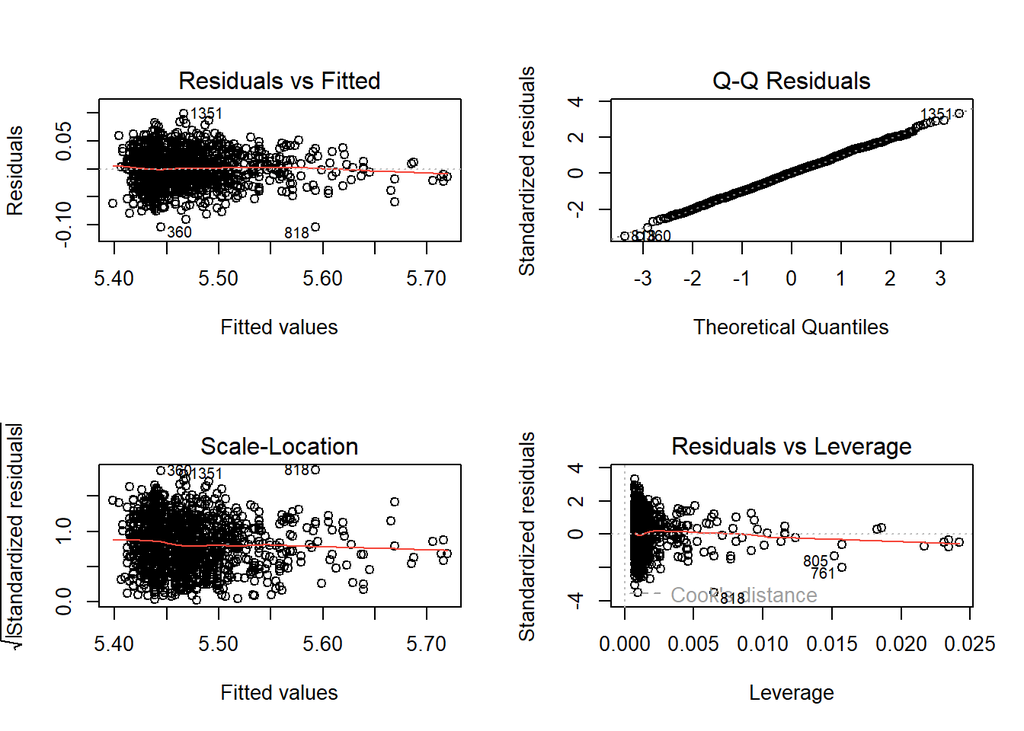

```r
par (mfrow=c(2,2))
plot(modelo_LogLin)
```

Al haber realizado la transformación logarítmica de la *variable Y*, los resultados muestran que,la transformación Log-Lin produce un valor de R² de apróximadamente *0.69* ligeramente inferior al del modelo original. Aunque también se reduce el R², el modelo sigue siendo significativo, como lo indica el estadístico valor de p (p-value), confirmando así la relación que existe entre las variables continúa siendo estadísticamente relevante.

## **8.3. Transformación Log-Log**

```r
modelo_LogLog = lm(log(preciom) ~ log(areaconst), data=aptos)
summary(modelo_LogLog)
```

```
##
## Call:
## lm(formula = log(preciom) ~ log(areaconst), data = aptos)
##
## Residuals:
##       Min        1Q    Median        3Q       Max
## -0.104409 -0.022224  0.000044  0.020791  0.093492
##
## Coefficients:
##                Estimate Std. Error t value Pr(>|t|)
## (Intercept)     4.72964    0.01421  332.74   <2e-16 ***
## log(areaconst)  0.17250    0.00331   52.11   <2e-16 ***
## ---
## Signif. codes:  0 '***' 0.001 '**' 0.01 '*' 0.05 '.' 0.1 ' ' 1
##
## Residual standard error: 0.03091 on 1359 degrees of freedom
## Multiple R-squared:  0.6665, Adjusted R-squared:  0.6662
## F-statistic:  2716 on 1 and 1359 DF,  p-value: < 2.2e-16
```

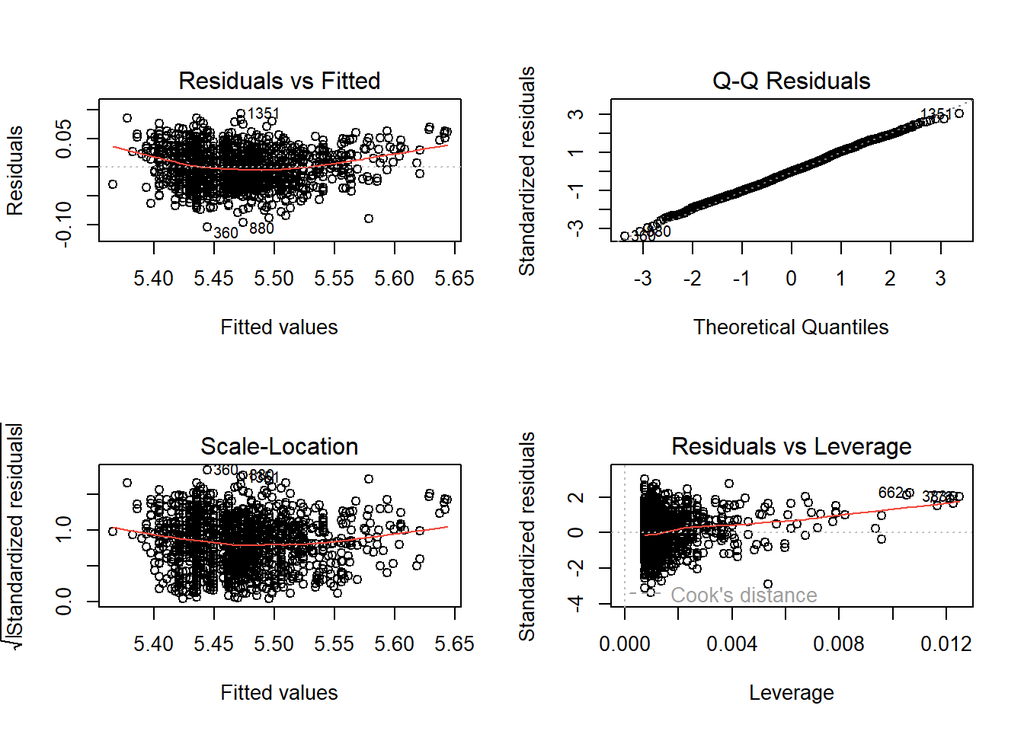

```r
par (mfrow=c(2,2))
plot(modelo_LogLog)
```

Al haber realizado la transformación logarítmica de la *variable X* y la *variable Y*, los resultados muestran que con la transformación Log-Log, el valor de R² disminuye a *0.67* apróximadamente, siendo inferior al del modelo original y a los modelos Lin-Log y Log-Lin. No obstante, el estadístico p-value sigue siendo significativo, lo que indica que la relación entre las variables, aunque menos explicativa en comparación con los otros modelos, sigue siendo estadísticamente significativa.